# Time Series CV - Arima Models

Tiago Souza

4/25/2022

## Step 0: Parameters

```r
# Number of periods to forecast
forecast_length <- 6
# Number of periods in test sample
test_size <- forecast_length
# Initial number of periods included in a split
initial_periods <- 36
# Number of splits in output
splits_number <- 10
# Parameter used not in arima models, set to 0 here
lag_max <- 0
# Metrics
multi_metric <- metric_set(rmse, mae, mape) # Problem with rsq()
# Chosen metric
metric_chosen <- "mae"
# Number of models to average
n_models_avg <- 3
```

## Step 1: Download and tidy data

In this example we will use Manufacturing production data from Brazil.

```r
data_links <- list(
  manufacturing = "https://apisidra.ibge.gov.br/values/t/3653/v/3134/c544/129316/p/all/n1/all",
  retail = "https://apisidra.ibge.gov.br/values/t/3417/v/1186/c11046/40312/p/all/n1/all")

download_data <- function(url) {
  data <- GET(url = url) %>%
    content(as = "parsed") %>%
    map_dfr(., ~.)
}

data <- map_dfr(data_links, download_data, .id = "variable") %>%

  filter(NC == "1") %>%

  transmute(
    variable = variable,
    date = ymd(paste0(D3C,"01")),
    value = as.numeric(V)) %>%

  group_by(variable) %>%

  mutate(value = value / lag(value, n=1) - 1) %>%

  drop_na() %>%

  ungroup()

print(data)
```

```
## # A tibble: 468 × 3
##    variable      date          value
##    <chr>         <date>        <dbl>
##  1 manufacturing 2002-02-01  0.0306
##  2 manufacturing 2002-03-01 -0.00990
##  3 manufacturing 2002-04-01  0.00500
##  4 manufacturing 2002-05-01 -0.00373
##  5 manufacturing 2002-06-01  0.00125
##  6 manufacturing 2002-07-01  0.00748
##  7 manufacturing 2002-08-01 -0.00743
##  8 manufacturing 2002-09-01  0.00499
##  9 manufacturing 2002-10-01  0.00248
## 10 manufacturing 2002-11-01 -0.00248
## # … with 458 more rows
```

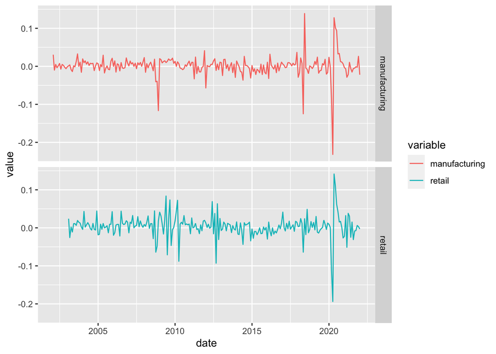

```r
data %>%
  ggplot(aes(x = date, y = value, color = variable)) +
  geom_line() +
  facet_grid(variable ~ .)
```

## Step 2: Define models

Here we define a set of models and the names of their respective recipes. What defines one specification is a pair model-recipe.

```r
seasonal_per <- timetk::tk_get_frequency(data %>%
                                           filter(variable == "manufacturing") %>%
                                           pull(date),
                                         period = "auto",
                                         message = FALSE)

define_model <- function(model_id, seasonal_per = seasonal_per){

    model_id <- str_split(model_id, "\\.") %>%
      extract2(1) %>%
      as.numeric()

    p <- model_id[1]
    d <- model_id[2]
    q <- model_id[3]
    P <- model_id[4]
    D <- model_id[5]
    Q <- model_id[6]

    model <- modeltime::arima_reg(
      seasonal_period = seasonal_per,
      non_seasonal_ar = p,
      non_seasonal_differences = d,
      non_seasonal_ma = q,
      seasonal_ar = P,
      seasonal_differences = D,
      seasonal_ma = Q
    ) %>%

      set_engine("arima")

      return(model)

  }

  grid_arima <- expand_grid(p = 0:4,
                            d = 0,
                            q = 0:1,
                            P = 0,
                            D = 0,
                            Q = 0) %>%
    unite("model_id", p:Q, sep = ".")

  models_def <- grid_arima %>%

    mutate(
      recipe_id = "recipe_arima",
      workflow = map(model_id, ~
                       workflow() %>%
                       add_model(define_model(.x,seasonal_per)))
      )

head(models_def)
```

```
## # A tibble: 6 × 3
##   model_id    recipe_id    workflow
##   <chr>       <chr>        <list>
## 1 0.0.0.0.0.0 recipe_arima <workflow>
## 2 0.0.1.0.0.0 recipe_arima <workflow>
## 3 1.0.0.0.0.0 recipe_arima <workflow>
## 4 1.0.1.0.0.0 recipe_arima <workflow>
## 5 2.0.0.0.0.0 recipe_arima <workflow>
## 6 2.0.1.0.0.0 recipe_arima <workflow>
```

## Step 3: Split Data - train/test

To clarify:

- **data**: complete set of data
- **data_train**: subset of ‘data’ to proceed with estimation via cross-validation
- **data_test**: subset ‘data’ to test performance at the end
- **data_extended**: original ‘data’ with the future periods appended at the end
- **data_future**: just the future periods

```r
data_complete <- data %>%

  group_nest(variable) %>%

  mutate(
    data_split = map(data, ~ .x %>% time_series_split(
                                      date_var = date,
                                      initial = initial_periods,
                                      assess = test_size,
                                      lag = lag_max,
                                      cumulative = TRUE,
                                      slice = 1)),
    data_train = map(data_split, ~ .x %>% training()),
    data_test = map(data_split, ~ .x %>% testing()),
    data_extended = map(data, ~ .x %>% timetk::future_frame(
                                        .date_var = date,
                                        .length_out = forecast_length,
                                        .bind_data = TRUE)),
    data_forecast = map(data_extended, ~ .x %>% filter(is.na(value)))
    ) %>%

  select(-data_split)

print(data_complete)
```

```
## # A tibble: 2 × 6
##   variable                 data data_train data_test data_extended data_forecast
##   <chr>         <list<tibble[,> <list>     <list>    <list>        <list>
## 1 manufacturing       [240 × 2] <tibble>   <tibble>  <tibble>      <tibble>
## 2 retail              [228 × 2] <tibble>   <tibble>  <tibble>      <tibble>
```

## Step 4: Split Data - CV

Remember that a recipe is defined by an equation and a data set. Hence, before creating recipes, we must split the training data.

```r
data_splits <- data_complete %>%

  transmute(
    variable = variable,
    split = map(data_train, ~ .x %>% time_series_cv(
                                      date_var = date,
                                      initial = initial_periods,
                                      assess = forecast_length,
                                      lag = lag_max,
                                      cumulative = TRUE,
                                      slice_limit = splits_number))) %>%

  unnest(split) %>%

  rename(split_id = id,
         split = splits)

head(data_splits)
```

```
## # A tibble: 6 × 3
##   variable      split           split_id
##   <chr>         <list>          <chr>
## 1 manufacturing <split [228/6]> Slice01
## 2 manufacturing <split [227/6]> Slice02
## 3 manufacturing <split [226/6]> Slice03
## 4 manufacturing <split [225/6]> Slice04
## 5 manufacturing <split [224/6]> Slice05
## 6 manufacturing <split [223/6]> Slice06
```

## Step 5: Recipes

Since a recipe is defined by a model and a data set, we define a function that will receive each component of a recipe and create it.

```r
create_recipe <- function(data, recipe_id) {

  data <- tryCatch(training(data),
                   error = function(e) data)

  recipe_arima <- recipe(value ~ date, data = data)

  return(get(recipe_id))

}
```

## Step 6: Complete tibble with all components

```r
models_components <- models_def %>%

  expand_grid(data_splits) %>%

  mutate(
    recipe = map2(split, recipe_id, ~ create_recipe(.x, .y)),
    workflow = map2(workflow, recipe, ~ .x %>% add_recipe(.y))
    ) %>%

  select(-recipe)

head(models_components)
```

```
## # A tibble: 6 × 6
##   model_id    recipe_id    workflow   variable      split           split_id
##   <chr>       <chr>        <list>     <chr>         <list>          <chr>
## 1 0.0.0.0.0.0 recipe_arima <workflow> manufacturing <split [228/6]> Slice01
## 2 0.0.0.0.0.0 recipe_arima <workflow> manufacturing <split [227/6]> Slice02
## 3 0.0.0.0.0.0 recipe_arima <workflow> manufacturing <split [226/6]> Slice03
## 4 0.0.0.0.0.0 recipe_arima <workflow> manufacturing <split [225/6]> Slice04
## 5 0.0.0.0.0.0 recipe_arima <workflow> manufacturing <split [224/6]> Slice05
## 6 0.0.0.0.0.0 recipe_arima <workflow> manufacturing <split [223/6]> Slice06
```

## Step 7: Fitting models to all splits

```r
models_fitted <- models_components %>%

  mutate(fit = map2(workflow, split, ~ tryCatch(fit(.x, data = training(.y)),
                                                error = function(error) NA))) %>%

  select(-workflow) %>%

  filter(!is.na(fit))

head(models_fitted)
```

```
## # A tibble: 6 × 6
##   model_id    recipe_id    variable      split           split_id fit
##   <chr>       <chr>        <chr>         <list>          <chr>    <list>
## 1 0.0.0.0.0.0 recipe_arima manufacturing <split [228/6]> Slice01  <workflow>
## 2 0.0.0.0.0.0 recipe_arima manufacturing <split [227/6]> Slice02  <workflow>
## 3 0.0.0.0.0.0 recipe_arima manufacturing <split [226/6]> Slice03  <workflow>
## 4 0.0.0.0.0.0 recipe_arima manufacturing <split [225/6]> Slice04  <workflow>
## 5 0.0.0.0.0.0 recipe_arima manufacturing <split [224/6]> Slice05  <workflow>
## 6 0.0.0.0.0.0 recipe_arima manufacturing <split [223/6]> Slice06  <workflow>
```

## Step 8: Calibrated data for test sample

```r
data_calibr <- models_fitted %>%

  mutate(
    fitted_recipe = map(fit, ~ extract_recipe(.x)),
    fitted_model = map(fit, ~ extract_fit_parsnip(.x)),
    data = map(split, ~ testing(.x)),
    data_test = map2(fitted_recipe, data, ~ bake(.x, .y)),
    pred = map2(fitted_model, data_test, ~ predict(.x, new_data = .y %>% select(-value))),
    across(c(data, pred), ~ map(.x, function(x) slice_tail(x, n = forecast_length))),
    data = map2(data, pred, ~ .x %>% bind_cols(.y))
  ) %>%

  select(variable,
         model_id,
         recipe_id,
         split_id,
         data) %>%

  unnest(data)

head(data_calibr)
```

```
## # A tibble: 6 × 7
##   variable      model_id    recipe_id    split_id date          value   .pred
##   <chr>         <chr>       <chr>        <chr>    <date>        <dbl>   <dbl>
## 1 manufacturing 0.0.0.0.0.0 recipe_arima Slice01  2021-02-01 -0.00660 0.00109
## 2 manufacturing 0.0.0.0.0.0 recipe_arima Slice01  2021-03-01 -0.0288  0.00109
## 3 manufacturing 0.0.0.0.0.0 recipe_arima Slice01  2021-04-01 -0.0217  0.00109
## 4 manufacturing 0.0.0.0.0.0 recipe_arima Slice01  2021-05-01  0.0105  0.00109
## 5 manufacturing 0.0.0.0.0.0 recipe_arima Slice01  2021-06-01 -0.00577 0.00109
## 6 manufacturing 0.0.0.0.0.0 recipe_arima Slice01  2021-07-01 -0.0151  0.00109
```

## Step 9: Error metrics

```r
error_metrics <- data_calibr %>%

  group_by(variable, model_id, recipe_id, split_id) %>%

  multi_metric(value, .pred) %>%

  group_by(variable, model_id, recipe_id, .metric) %>%

  summarize(mean_error = mean(.estimate), .groups = "drop_last")

head(error_metrics)
```

```
## # A tibble: 6 × 5
## # Groups:   variable, model_id, recipe_id [2]
##   variable      model_id    recipe_id    .metric mean_error
##   <chr>         <chr>       <chr>        <chr>        <dbl>
## 1 manufacturing 0.0.0.0.0.0 recipe_arima mae         0.0242
## 2 manufacturing 0.0.0.0.0.0 recipe_arima mape      103.
## 3 manufacturing 0.0.0.0.0.0 recipe_arima rmse        0.0300
## 4 manufacturing 0.0.1.0.0.0 recipe_arima mae         0.0250
## 5 manufacturing 0.0.1.0.0.0 recipe_arima mape      105.
## 6 manufacturing 0.0.1.0.0.0 recipe_arima rmse        0.0315
```

## Step 10: Best model

The metric of choice will be “MAE”.

```r
best_model <- error_metrics %>%

  filter(.metric == metric_chosen) %>%

  group_by(variable) %>%

  slice_min(mean_error, n = n_models_avg) %>%

  select(variable, model_id, recipe_id)

head(best_model)
```

```
## # A tibble: 6 × 3
## # Groups:   variable [2]
##   variable      model_id    recipe_id
##   <chr>         <chr>       <chr>
## 1 manufacturing 0.0.0.0.0.0 recipe_arima
## 2 manufacturing 1.0.0.0.0.0 recipe_arima
## 3 manufacturing 0.0.1.0.0.0 recipe_arima
## 4 retail        0.0.0.0.0.0 recipe_arima
## 5 retail        1.0.0.0.0.0 recipe_arima
## 6 retail        0.0.1.0.0.0 recipe_arima
```

## Step 11: Refit best models

```r
refit_models <- best_model %>%

  left_join(data_complete, by = "variable") %>%

  left_join(models_def, by = c("model_id", "recipe_id")) %>%

  mutate(
    recipe = map2(data_train, recipe_id, ~ create_recipe(.x, .y)),
    workflow = map2(workflow, recipe, ~ .x %>% add_recipe(.y)),
    fit = map2(workflow, data_train, ~ fit(.x, data = .y)),
    fitted_recipe = map(fit, ~ extract_recipe(.x)),
    fitted_model = map(fit, ~ extract_fit_parsnip(.x))
  ) %>%

  ungroup()

head(refit_models)
```

```
## # A tibble: 6 × 13
##   variable      model_id  recipe_id      data data_train data_test data_extended
##   <chr>         <chr>     <chr>     <list<ti> <list>     <list>    <list>
## 1 manufacturing 0.0.0.0.… recipe_a… [240 × 2] <tibble>   <tibble>  <tibble>
## 2 manufacturing 1.0.0.0.… recipe_a… [240 × 2] <tibble>   <tibble>  <tibble>
## 3 manufacturing 0.0.1.0.… recipe_a… [240 × 2] <tibble>   <tibble>  <tibble>
## 4 retail        0.0.0.0.… recipe_a… [228 × 2] <tibble>   <tibble>  <tibble>
## 5 retail        1.0.0.0.… recipe_a… [228 × 2] <tibble>   <tibble>  <tibble>
## 6 retail        0.0.1.0.… recipe_a… [228 × 2] <tibble>   <tibble>  <tibble>
## # … with 6 more variables: data_forecast <list>, workflow <list>,
## #   recipe <list>, fit <list>, fitted_recipe <list>, fitted_model <list>
```

## Step 12: Performance with respect to test data

```r
data_perf <- refit_models %>%

  select(variable,
         data_test,
         fitted_recipe,
         fitted_model) %>%

  mutate(
    data_test = map2(fitted_recipe, data_test, ~ bake(.x, .y)),
    pred = map2(fitted_model, data_test, ~ predict(.x, new_data = .y)),
    data_test = map2(data_test, pred,
                     ~ .x %>%
                       select(value) %>%
                       bind_cols(.y) %>%
                       mutate(horizon = row_number()))
  ) %>%

  select(
    variable,
    data_test
  ) %>%

  unnest(data_test) %>%

  group_by(variable, horizon) %>%

  summarize(
    value = mean(value),
    .pred = mean(.pred),
    .groups = "drop"
  )

head(data_perf)
```

```
## # A tibble: 6 × 4
##   variable      horizon    value    .pred
##   <chr>           <int>    <dbl>    <dbl>
## 1 manufacturing       1 -0.00589 0.000945
## 2 manufacturing       2 -0.00474 0.000771
## 3 manufacturing       3 -0.00119 0.000772
## 4 manufacturing       4 -0.00238 0.000772
## 5 manufacturing       5  0.0263  0.000772
## 6 manufacturing       6 -0.0221  0.000772
```

## Step 11: Forecasts

Now we turn to forecasting the future, and for that we will need a recursive approach. This is needed since to forecast $n$ periods ahead, given the existence of lag variables in the models, it is needed to have the forecast for the $n-1$ previous periods.

```r
final <- refit_models %>%

  mutate(
    pred = map2(fitted_recipe, data_extended, ~ bake(.x, .y)),
    pred = map(pred, ~ .x %>%
                          filter(is.na(value)) %>%
                          select(-value)),
    pred = map2(fitted_model, pred, ~ predict(.x, new_data = .y) %>% rename(value = .pred)),
    pred = map2(data_forecast, pred,
                         ~ .x %>%
                           select(-value) %>%
                           bind_cols(.y)),
    data_forecast = map2(data_forecast, pred, ~ .x %>% rows_update(.y, by = "date")),
    data_extended = map2(data_extended, pred, ~ .x %>% rows_update(.y, by = "date"))
    ) %>%

  select(variable,
         data_forecast)

final <- final %>%

  select(variable,
         data_forecast) %>%

  unnest(data_forecast) %>%

  group_by(variable, date) %>%

  summarize(value = value,
            .groups = "drop")

final <- final %>%

  group_nest(variable, .key = "data_forecast") %>%

  left_join(data_complete %>%
              select(variable, data), by = "variable")

head(final)
```

```
## # A tibble: 2 × 3
##   variable           data_forecast               data
##   <chr>         <list<tibble[,2]>> <list<tibble[,2]>>
## 1 manufacturing           [18 × 2]          [240 × 2]
## 2 retail                  [18 × 2]          [228 × 2]
```

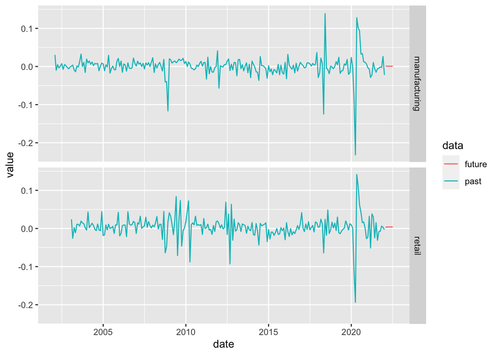

```r
plot_final <- final %>%

  select(-data_forecast) %>%

  unnest(data) %>%

  mutate(data = "past") %>%

  bind_rows(final %>%
              select(-data) %>%
              unnest(data_forecast) %>%
              mutate(data = "future"))

plot_final %>%

  ggplot(aes(x = date, y = value, color = data)) +
    geom_line() +
    facet_grid(variable ~ .)
```